# Random Rectangles

Mike Hitchman

Fall ’22

# The Scene

On the random rectangles worksheet, each of you used three methods to estimate the average area of the 100 apartments printed on the back of the activity. Let’s take a look at the class results

# Import the data

```r
df <- read.csv("https://mphitchman.com/stats/data/rectanglesF22.csv")
```

You can run this line of code at the console prompt in RStudio (copy and paste!) to load the survey data into your own RStudio session. The code loads the data and gives it the working name `df` in your session.

Here’s a look at the first 5 rows of the data frame

```r
head(df,5)
```

```
##   student method1 method2 method3
## 1       1       9    14.4     5.0
## 2       2      10     9.2     6.4
## 3       3      10    13.6     7.8
## 4       4      16     6.8    28.8
## 5       5      13     9.0     7.8
```

# Method 1 Estimates

```r
mean(df$method1)
```

```
## [1] 12.61538
```

```r
sd(df$method1)
```

```
## [1] 7.115206
```

```r
fivenum(df$method1)
```

```
## [1]  5  9 10 15 37
```

Here’s a histogram of the Method 1 estimates

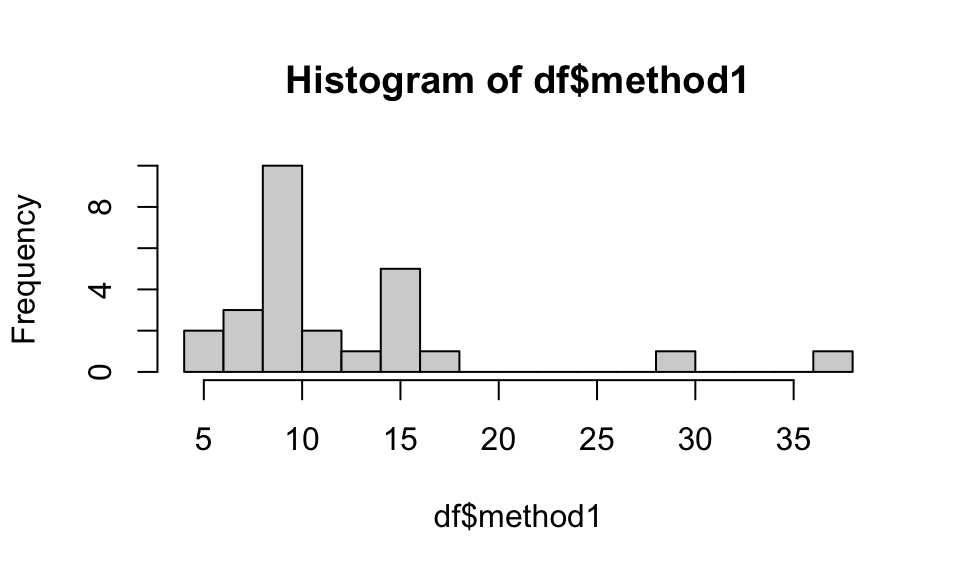

```r
hist(df$method1,breaks=12)
```

# Method 2 Estimates

```r
mean(df$method2)
```

```
## [1] 10.83846
```

```r
sd(df$method2)
```

```
## [1] 3.053664
```

```r
fivenum(df$method2)
```

```
## [1]  6.8  8.4 10.1 13.4 17.0
```

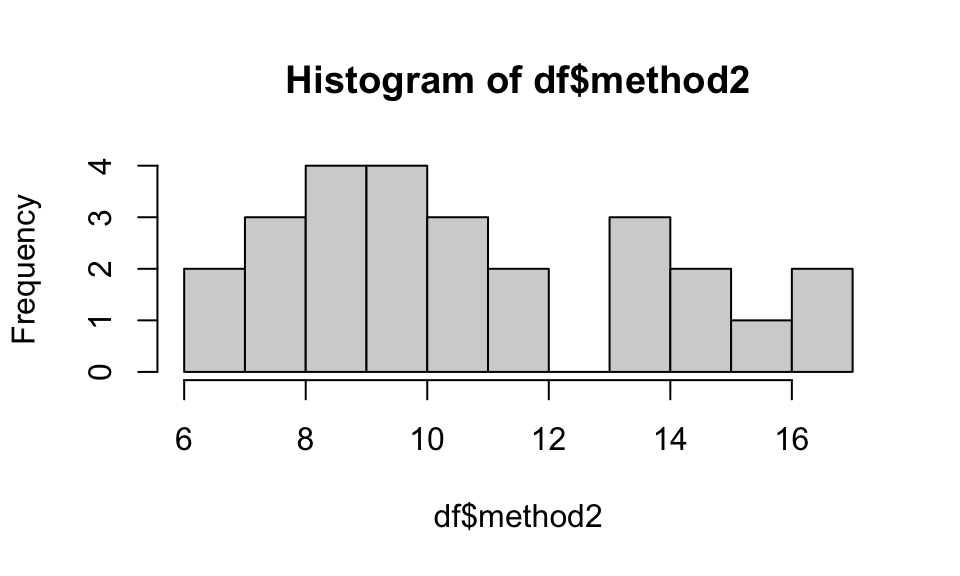

```r
hist(df$method2,breaks=12)
```

# Method 3 Estimates

```r
mean(df$method3)
```

```
## [1] 8.019231
```

```r
sd(df$method3)
```

```
## [1] 4.545593
```

```r
fivenum(df$method3)
```

```
## [1]  3.0  6.4  7.7  8.5 28.8
```

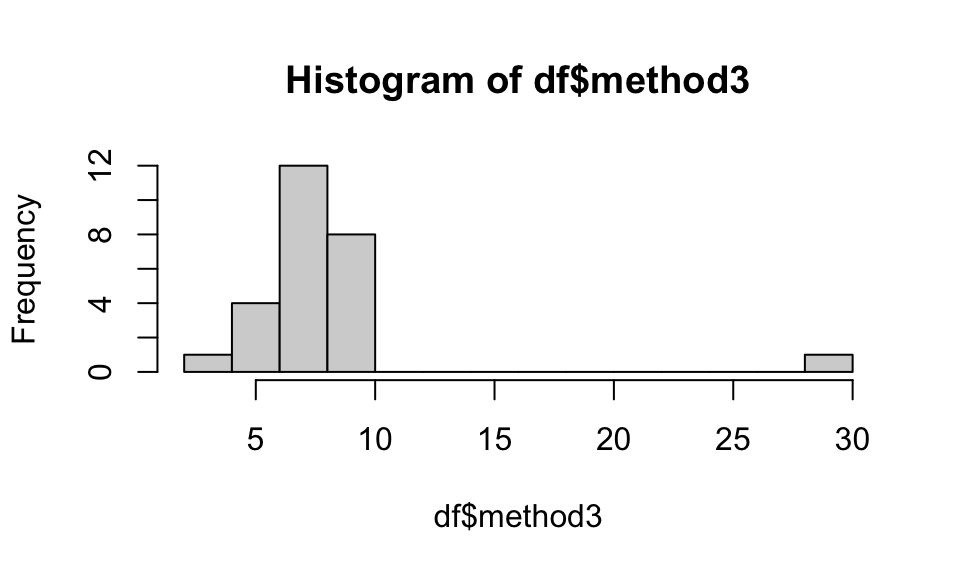

```r
hist(df$method3,breaks=12)
```

And side-by-side boxplots!

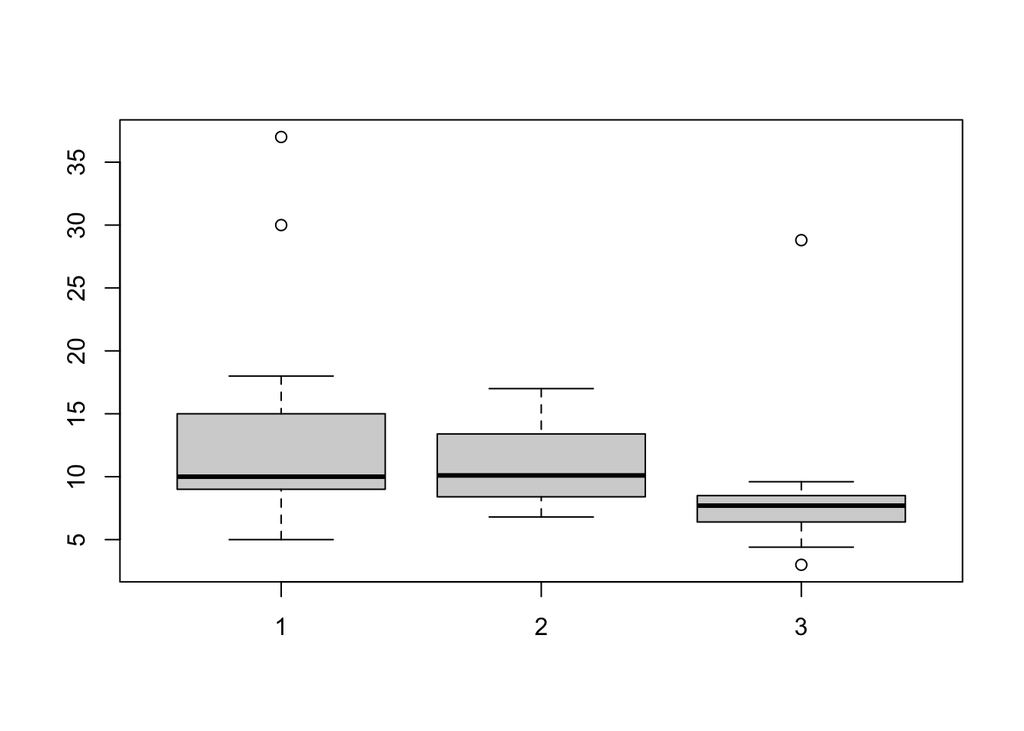

```r
boxplot(df$method1,df$method2,df$method3)
```

and if you’ve read this far, you are rewarded with this knowledge: the true average area of the 100 apartments is… 7.42.